Model-3 I am using Chest pain type,FBS over 120,slope of ST and number of vessels of fluro as predictors and considering all the predictor variables are not statistically significant with each other .I am going to set up the heart beat range as the prior_intercept while the prior normal as the week prior normal .Hence it is set as auto scale.

```r
dataset3=dataset%>%select(Chest.pain.type,FBS.over.120,Slope.of.ST,Number.of.vessels.fluro,Max.HR)
model_3 <- stan_glm(
  Max.HR~Chest.pain.type+FBS.over.120+Slope.of.ST+Number.of.vessels.fluro,
  data = dataset3, family = gaussian,
  prior_intercept = normal(71,65.5),
  prior = normal(0, 1, autoscale = TRUE),
  prior_aux = exponential(1, autoscale = TRUE),
  chains = 4, iter = 5000*2, seed = 84735,prior_PD = TRUE)
summary(model_3)
```

```
##
## Model Info:
##  function:     stan_glm
##  family:       gaussian [identity]
##  formula:      Max.HR ~ Chest.pain.type + FBS.over.120 + Slope.of.ST + Number.of.vessels.fluro
##  algorithm:    sampling
##  sample:       20000 (posterior sample size)
##  priors:       see help('prior_summary')
##  observations: 270
##  predictors:   5
##
## Estimates:
##                           mean   sd    10%   50%   90%
## (Intercept)              71.6  119.1 -81.6  71.7 224.6
## Chest.pain.type           0.1   24.2 -31.3   0.2  31.3
## FBS.over.120             -0.1   65.9 -84.5  -0.5  84.7
## Slope.of.ST              -0.2   37.6 -48.7  -0.3  47.5
## Number.of.vessels.fluro   0.1   24.6 -31.3   0.2  31.5
## sigma                    23.1   23.1   2.5  16.0  53.1
##
## MCMC diagnostics
##                         mcse Rhat n_eff
## (Intercept)             0.8  1.0  21486
## Chest.pain.type         0.2  1.0  22535
## FBS.over.120            0.4  1.0  21497
## Slope.of.ST             0.3  1.0  22650
## Number.of.vessels.fluro 0.2  1.0  20953
## sigma                   0.1  1.0  24269
## log-posterior           0.0  1.0   8934
##
## For each parameter, mcse is Monte Carlo standard error, n_eff is a crude measure of effective sample size, and Rhat is the potential scale reduction factor on split chains (at convergence Rhat=1).
```

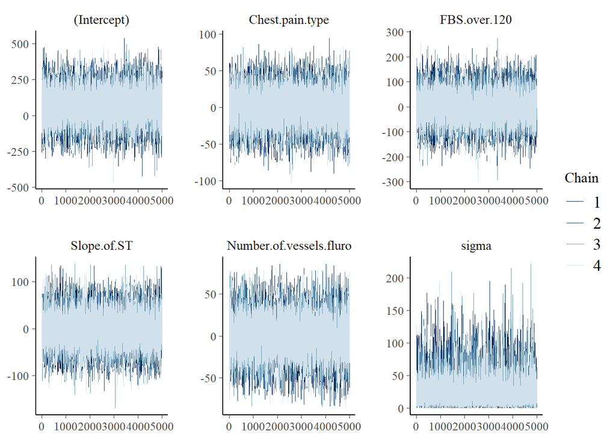

```r
mcmc_trace(model_3, size = 0.1)
```

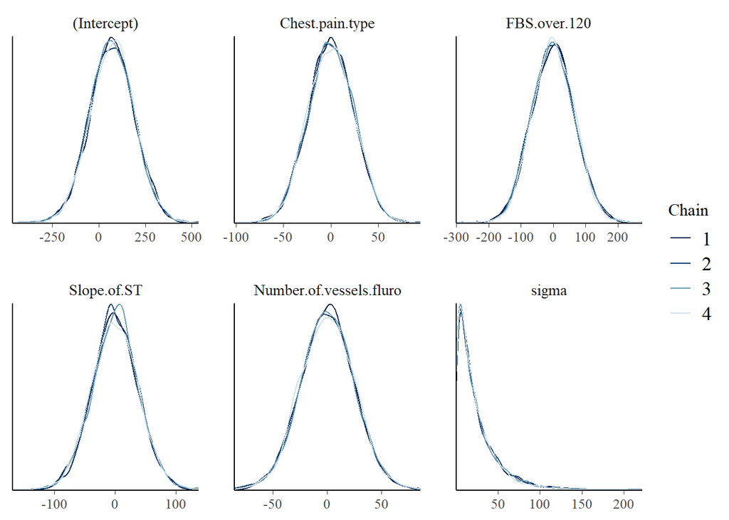

```r
mcmc_dens_overlay(model_3)
```

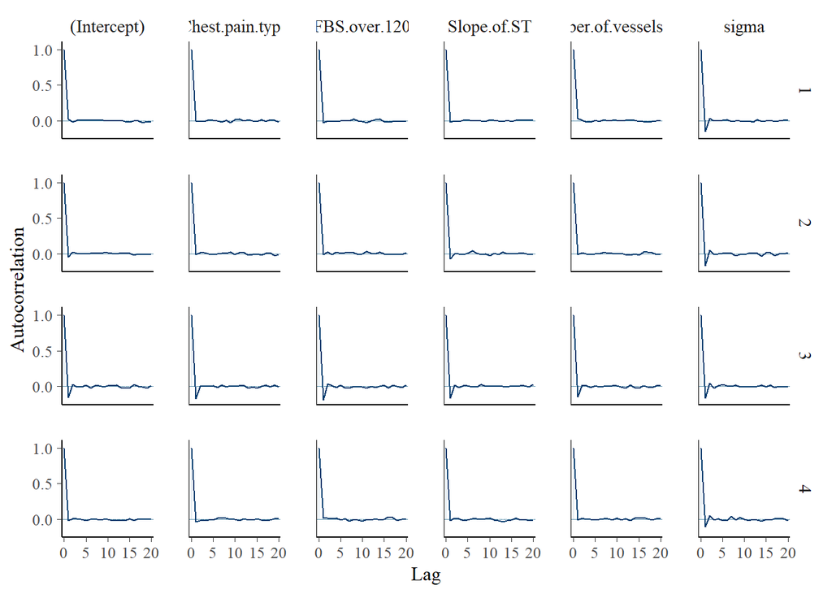

```r
mcmc_acf(model_3)
```

```r
neff_ratio(model_3)
```

```
##             (Intercept)         Chest.pain.type            FBS.over.120
##                 1.07430                 1.12675                 1.07485
##             Slope.of.ST Number.of.vessels.fluro                   sigma
##                 1.13250                 1.04765                 1.21345
```

The mcmc_trance function is used to denote the chains .The chains produced for the above model appears to be mixed well together .Hence they are considered as the stable.